# Reproducible Research: Course Project 1

## Imputing missing values

Note that there are a number of days/intervals where there are missing values (coded as NA). The presence of missing days may introduce bias into some calculations or summaries of the data.

1.-Calculate and report the total number of missing values in the dataset (i.e. the total number of rows with NAs).

2.- Devise a strategy for filling in all of the missing values in the dataset. The strategy does not need to be sophisticated. For example, you could use the mean/median for that day, or the mean for that 5-minute interval, etc.

3.- Create a new dataset that is equal to the original dataset but with the missing data filled in.

```r
# total number of missing values
df_missing <- activity %>%
  filter(is.na(steps)) %>%
  group_by(steps) %>%
  summarise(n=n()) %>%
  ungroup() %>%
  data.frame()
head(df_missing)
```

```
##   steps    n
## 1    NA 2304
```

In order not to alter the average of each step in each interval, I consider that a good alternative is to replace the missing values with the average of each step in each interval.

```r
# mean of each step
df04 <- base01 %>%
  group_by(interval) %>%
  summarise(MeanSteps = mean(steps)) %>%
  ungroup() %>%
  data.frame() %>%
  arrange(desc(MeanSteps))
head(df04)
```

```
##   interval MeanSteps
## 1      835  206.1698
## 2      840  195.9245
## 3      850  183.3962
## 4      845  179.5660
## 5      830  177.3019
## 6      820  171.1509
```

```r
# Code to describe and show a strategy for imputing missing data
activity.imp <- activity %>% filter(is.na(steps))
for(j in 1: nrow(df04)){
  for(i in 1:nrow(activity.imp)){
    if(is.na(activity.imp[i,1]) & activity.imp[i,3]==df04[j,1]){
      activity.imp[i,1] <- df04[j,2]
    }else{
      i <- i+1
    }
  }
}

activity.cleaned <- rbind(activity.imp%>%mutate(date=as.Date(date)),base01)
dim(activity)
```

```
## [1] 17568     3
```

```r
dim(activity.cleaned)
```

```
## [1] 17568     3
```

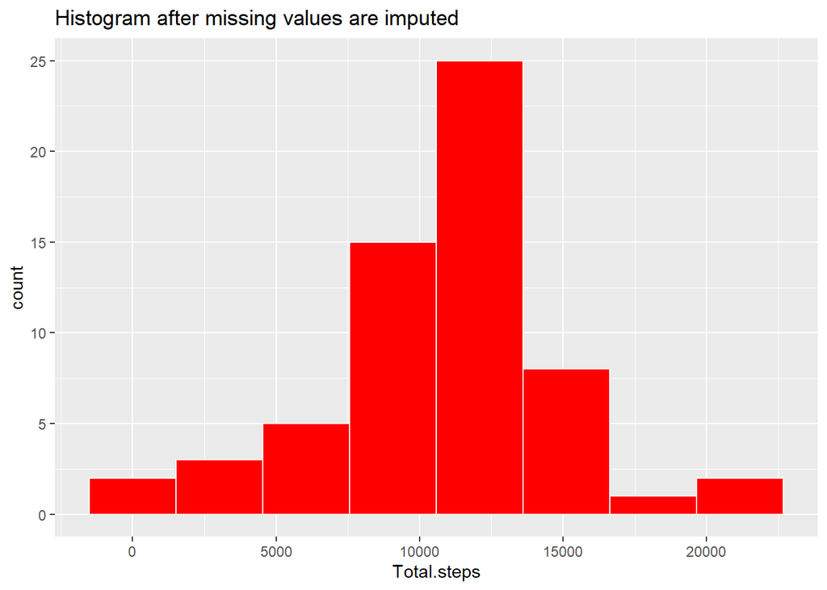

```r
df01.2 <- activity.cleaned %>%
  group_by(date) %>%
  summarise(Total.steps=sum(steps)) %>%
  ungroup() %>%
  data.frame()

# histogram after missing values
p3 <- ggplot(df01.2,aes(x=Total.steps)) +
  geom_histogram(bins =8 , color="white", fill="red") +
  ggtitle("Histogram after missing values are imputed ")
p3
```

## Are there differences in activity patterns between weekdays and weekends?

For this part the weekdays() function may be of some help here. Use the dataset with the filled-in missing values for this part.

1.- Create a new factor variable in the dataset with two levels – “weekday” and “weekend” indicating whether a given date is a weekday or weekend day.

2.- Make a panel plot containing a time series plot (i.e. type = “l”) of the 5-minute interval (x-axis) and the average number of steps taken, averaged across all weekday days or weekend days (y-axis). See the README file in the GitHub repository to see an example of what this plot should look like using simulated data.

```r
df05 <- activity.cleaned %>%
  mutate(weekdays=weekdays(as.Date(date)),
         type = ifelse(weekdays == "sábado" | weekdays == "domingo","weekend","weekday"))%>%
  group_by(type,interval) %>%
  summarise(avg.steps=mean(steps)) %>%
  ungroup() %>%
  data.frame()
head(df05)
```

```
##      type interval  avg.steps
## 1 weekday        0 2.25115304
## 2 weekday        5 0.44528302
## 3 weekday       10 0.17316562
## 4 weekday       15 0.19790356
## 5 weekday       20 0.09895178
## 6 weekday       25 1.59035639
```

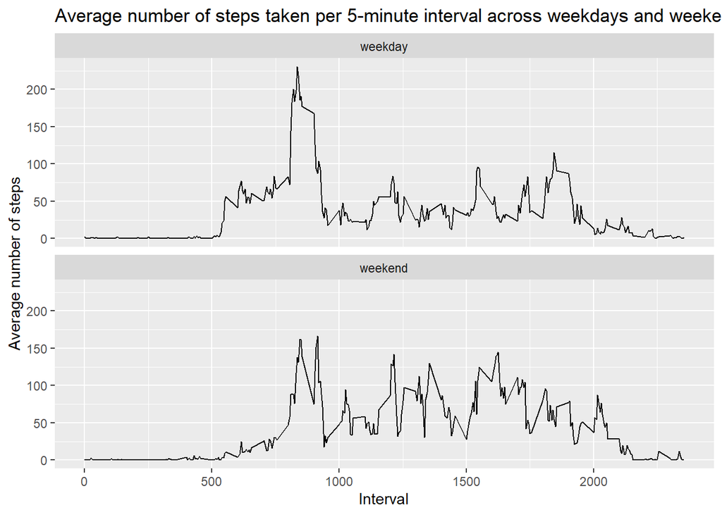

```r
# Panel plot
p4 <- ggplot(df05,aes(x=interval,y=avg.steps)) +
  geom_line() +
  facet_wrap(facets="type",nrow=2) +
  ggtitle("Average number of steps taken per 5-minute interval across weekdays and weekends") +
  xlab("Interval") +
  ylab("Average number of steps")
p4
```